# Ethan Campbell HW5

Fort Worth climate change based on precipitation, humidity, and temperature from 1981-2020

Ethan Campbell  
2022-03-15

# Introduction/Importing data

Importing and viewing the data to determine major cleaning changes that need to be made. Here we notice that all the months are separated and that the PARAMETER column holds all of the unique values. I want to combine the months into one column and then spread the unique values. Once I complete this I can select the columns that I want and then remove the Na values. When I have this setup I will be able to run an analysis on the specific segment that I want.

```r
Fort_Worth <- read.csv("Fort_Worth_climate.csv", skip = 18)

Fort_Worth %>%
  slice(1:12) %>%
  knitr::kable(caption = "Original Table", digits = 2) %>%
  kableExtra::kable_styling(bootstrap_options = "striped", full_width = TRUE)
```

Table 1: Original Table

| PARAMETER | YEAR | JAN | FEB | MAR | APR | MAY | JUN | JUL | AUG | SEP | OCT | NOV | DEC | ANN |
| --- | --- | --- | --- | --- | --- | --- | --- | --- | --- | --- | --- | --- | --- | --- |
| PS | 1981 | 99.17 | 99.00 | 98.53 | 98.64 | 98.18 | 98.29 | 98.49 | 98.45 | 98.65 | 98.69 | 98.76 | 98.81 | 98.64 |
| PS | 1982 | 98.81 | 99.11 | 98.50 | 98.52 | 98.27 | 98.28 | 98.51 | 98.53 | 98.58 | 98.76 | 98.83 | 98.78 | 98.62 |
| PS | 1983 | 98.91 | 98.51 | 98.06 | 98.08 | 98.23 | 98.26 | 98.63 | 98.59 | 98.65 | 98.80 | 98.37 | 99.20 | 98.53 |
| PS | 1984 | 99.40 | 98.61 | 98.42 | 98.03 | 98.38 | 98.36 | 98.49 | 98.47 | 98.72 | 98.58 | 98.90 | 98.89 | 98.61 |
| PS | 1985 | 99.24 | 99.08 | 98.57 | 98.47 | 98.26 | 98.42 | 98.49 | 98.42 | 98.60 | 98.66 | 98.61 | 99.26 | 98.67 |
| PS | 1986 | 99.22 | 98.56 | 98.70 | 98.41 | 98.27 | 98.40 | 98.58 | 98.55 | 98.56 | 98.87 | 98.91 | 99.18 | 98.69 |
| PS | 1987 | 98.84 | 98.61 | 98.53 | 98.61 | 98.38 | 98.49 | 98.54 | 98.45 | 98.56 | 99.00 | 98.90 | 98.79 | 98.64 |
| PS | 1988 | 99.33 | 99.13 | 98.70 | 98.34 | 98.42 | 98.51 | 98.57 | 98.36 | 98.49 | 98.90 | 98.49 | 99.21 | 98.70 |
| PS | 1989 | 99.06 | 99.39 | 98.64 | 98.53 | 98.30 | 98.40 | 98.60 | 98.46 | 98.69 | 98.81 | 98.75 | 99.24 | 98.73 |
| PS | 1990 | 98.84 | 98.85 | 98.83 | 98.59 | 98.21 | 98.37 | 98.63 | 98.63 | 98.63 | 98.79 | 98.89 | 98.99 | 98.69 |
| PS | 1991 | 99.10 | 99.03 | 98.23 | 98.19 | 98.32 | 98.42 | 98.56 | 98.64 | 98.85 | 98.61 | 99.07 | 99.16 | 98.68 |
| PS | 1992 | 99.02 | 98.70 | 98.55 | 98.50 | 98.61 | 98.08 | 98.48 | 98.74 | 98.61 | 98.70 | 98.69 | 98.92 | 98.63 |

```r
Month_combined <- Fort_Worth %>%
pivot_longer(
  cols = c(NOV, JAN, FEB, MAR, APR, MAY, JUN, JUL, AUG, SEP, OCT, DEC),
  names_to = "MONTH",
  values_to = "Month_AVG",
)

Month_combined %>%
  select("PARAMETER", "YEAR", "MONTH", "Month_AVG", "ANN") %>%
  slice(1:12) %>%
  knitr::kable(caption = "Month Combined", digits = 2) %>%
  kableExtra::kable_styling(bootstrap_options = "striped", full_width = TRUE)
```

Table 1: Month Combined

| PARAMETER | YEAR | MONTH | Month_AVG | ANN |
| --- | --- | --- | --- | --- |
| PS | 1981 | NOV | 98.76 | 98.64 |
| PS | 1981 | JAN | 99.17 | 98.64 |
| PS | 1981 | FEB | 99.00 | 98.64 |
| PS | 1981 | MAR | 98.53 | 98.64 |
| PS | 1981 | APR | 98.64 | 98.64 |
| PS | 1981 | MAY | 98.18 | 98.64 |
| PS | 1981 | JUN | 98.29 | 98.64 |
| PS | 1981 | JUL | 98.49 | 98.64 |
| PS | 1981 | AUG | 98.45 | 98.64 |
| PS | 1981 | SEP | 98.65 | 98.64 |
| PS | 1981 | OCT | 98.69 | 98.64 |
| PS | 1981 | DEC | 98.81 | 98.64 |

```r
Para_split <- Month_combined %>%
  pivot_wider(names_from = PARAMETER,
              values_from = Month_AVG,
              )


Para_split %>%
  slice(1:12) %>%
  knitr::kable(caption = "PARAMETER split", digits = 2) %>%
  kableExtra::kable_styling(bootstrap_options = "striped", full_width = TRUE)
```

Table 1: PARAMETER split

| YEAR | ANN | MONTH | PS | TS | T2M | QV2M | RH2M | WD50M | WS10M | WS50M | PRECTOTCORR | PRECTOTCORR_SUM |
| --- | --- | --- | --- | --- | --- | --- | --- | --- | --- | --- | --- | --- |
| 1981 | 98.64 | NOV | 98.76 | NA | NA | NA | NA | NA | NA | NA | NA | NA |
| 1981 | 98.64 | JAN | 99.17 | NA | NA | NA | NA | NA | NA | NA | NA | NA |
| 1981 | 98.64 | FEB | 99.00 | NA | NA | NA | NA | NA | NA | NA | NA | NA |
| 1981 | 98.64 | MAR | 98.53 | NA | NA | NA | NA | NA | NA | NA | NA | NA |
| 1981 | 98.64 | APR | 98.64 | NA | NA | NA | NA | NA | NA | NA | NA | NA |
| 1981 | 98.64 | MAY | 98.18 | NA | NA | NA | NA | NA | NA | NA | NA | NA |
| 1981 | 98.64 | JUN | 98.29 | NA | NA | NA | NA | NA | NA | NA | NA | NA |
| 1981 | 98.64 | JUL | 98.49 | NA | NA | NA | NA | NA | NA | NA | NA | NA |
| 1981 | 98.64 | AUG | 98.45 | NA | NA | NA | NA | NA | NA | NA | NA | NA |
| 1981 | 98.64 | SEP | 98.65 | NA | NA | NA | NA | NA | NA | NA | NA | NA |
| 1981 | 98.64 | OCT | 98.69 | NA | NA | NA | NA | NA | NA | NA | NA | NA |
| 1981 | 98.64 | DEC | 98.81 | NA | NA | NA | NA | NA | NA | NA | NA | NA |

# Cleaning the Temperature column

```r
# Rename in the temperature column and then mutating to change from C to F and then rearranged in the order i want while removed the Na values.

Final_Temperature <- Para_split %>%
  rename(Temperature = T2M) %>%
  mutate(Temperature_F = Temperature * 9/5 + 32) %>%
  mutate(Annual_Temperature = ANN * 9/5 + 32) %>%
  select(YEAR, MONTH, Temperature_F, Annual_Temperature) %>%
  na.omit(Temperature_F)

Final_Temperature %>%
  slice(1:12) %>%
  knitr::kable(caption = "Temperature", digits = 2) %>%
  kableExtra::kable_styling(bootstrap_options = "striped", full_width = TRUE)
```

Table 2: Temperature

| YEAR | MONTH | Temperature_F | Annual_Temperature |
| --- | --- | --- | --- |
| 1981 | NOV | 53.24 | 64.45 |
| 1981 | JAN | 42.19 | 64.45 |
| 1981 | FEB | 47.93 | 64.45 |
| 1981 | MAR | 55.02 | 64.45 |
| 1981 | APR | 69.01 | 64.45 |
| 1981 | MAY | 70.27 | 64.45 |
| 1981 | JUN | 79.36 | 64.45 |
| 1981 | JUL | 86.67 | 64.45 |
| 1981 | AUG | 85.33 | 64.45 |
| 1981 | SEP | 76.17 | 64.45 |
| 1981 | OCT | 64.42 | 64.45 |
| 1981 | DEC | 42.94 | 64.45 |

```r
# When was Temperature the highest (Jul of 2011)

Final_Temperature %>%
  select(YEAR, MONTH, Temperature_F, Annual_Temperature) %>%
  arrange(desc(Temperature_F)) %>%
  slice(1:12) %>%
  knitr::kable(caption = "Highest Temerpature", digits = 2) %>%
  kableExtra::kable_styling(bootstrap_options = "striped", full_width = TRUE)
```

Table 2: Highest Temerpature

| YEAR | MONTH | Temperature_F | Annual_Temperature |
| --- | --- | --- | --- |
| 2011 | JUL | 94.23 | 67.51 |
| 2011 | AUG | 94.17 | 67.51 |
| 1998 | JUL | 93.24 | 67.17 |
| 1999 | AUG | 92.17 | 66.83 |
| 2000 | AUG | 91.87 | 65.71 |
| 1985 | AUG | 90.95 | 64.00 |
| 2006 | AUG | 90.34 | 67.37 |
| 2018 | JUL | 90.21 | 65.03 |
| 2001 | JUL | 90.05 | 64.78 |
| 1988 | AUG | 89.56 | 64.27 |
| 1993 | AUG | 89.56 | 63.05 |
| 2010 | AUG | 89.51 | 64.40 |

```r
# When was Temperature the lowest (Dec of 1983)

Final_Temperature %>%
  select(YEAR, MONTH, Temperature_F, Annual_Temperature) %>%
  arrange(Temperature_F) %>%
  na.omit(Temperature_F) %>%
  slice(1:12) %>%
  knitr::kable(caption = "Lowest Temperature", digits = 2) %>%
  kableExtra::kable_styling(bootstrap_options = "striped", full_width = TRUE)
```

Table 2: Lowest Temperature

| YEAR | MONTH | Temperature_F | Annual_Temperature |
| --- | --- | --- | --- |
| 1983 | DEC | 33.49 | 62.73 |
| 1985 | JAN | 34.29 | 64.00 |
| 1989 | DEC | 35.56 | 62.24 |
| 2000 | DEC | 35.69 | 65.71 |
| 1984 | JAN | 36.12 | 64.80 |
| 1988 | JAN | 37.26 | 64.27 |
| 2007 | JAN | 38.26 | 63.75 |
| 2009 | DEC | 38.68 | 64.51 |
| 1991 | JAN | 38.75 | 63.90 |
| 2010 | FEB | 39.04 | 64.40 |
| 2011 | JAN | 39.15 | 67.51 |
| 2001 | JAN | 39.22 | 64.78 |

```r
Final_Temperature %>%
  select(YEAR, MONTH, Temperature_F, Annual_Temperature) %>%
  filter(YEAR < 1982) %>%
  mutate(Mean = mean(Temperature_F)) %>%
  mutate(Standard_Deviation = sd(Temperature_F)) %>%
  mutate(Median = median(Temperature_F)) %>%
  slice(1:12) %>%
  knitr::kable(caption = "Temperature stats data", digits = 2) %>%
  kableExtra::kable_styling(bootstrap_options = "striped", full_width = TRUE)
```

Table 2: Temperature stats data

| YEAR | MONTH | Temperature_F | Annual_Temperature | Mean | Standard_Deviation | Median |
| --- | --- | --- | --- | --- | --- | --- |
| 1981 | NOV | 53.24 | 64.45 | 64.38 | 15.92 | 66.71 |
| 1981 | JAN | 42.19 | 64.45 | 64.38 | 15.92 | 66.71 |
| 1981 | FEB | 47.93 | 64.45 | 64.38 | 15.92 | 66.71 |
| 1981 | MAR | 55.02 | 64.45 | 64.38 | 15.92 | 66.71 |
| 1981 | APR | 69.01 | 64.45 | 64.38 | 15.92 | 66.71 |
| 1981 | MAY | 70.27 | 64.45 | 64.38 | 15.92 | 66.71 |
| 1981 | JUN | 79.36 | 64.45 | 64.38 | 15.92 | 66.71 |
| 1981 | JUL | 86.67 | 64.45 | 64.38 | 15.92 | 66.71 |
| 1981 | AUG | 85.33 | 64.45 | 64.38 | 15.92 | 66.71 |
| 1981 | SEP | 76.17 | 64.45 | 64.38 | 15.92 | 66.71 |
| 1981 | OCT | 64.42 | 64.45 | 64.38 | 15.92 | 66.71 |
| 1981 | DEC | 42.94 | 64.45 | 64.38 | 15.92 | 66.71 |

```r
Temperature_DEC <- Final_Temperature %>%
  select(YEAR, MONTH, Temperature_F, Annual_Temperature) %>%
  filter(MONTH == "DEC")

Temperature_July <- Final_Temperature %>%
  select(YEAR, MONTH, Temperature_F, Annual_Temperature) %>%
  filter(MONTH == "JUL")






Final_Precipitation <- Para_split %>%
  rename(Precipitation = PRECTOTCORR_SUM) %>%
  mutate(Precipitation_annual = ANN / 25.4) %>%
  mutate(Precipitation_Monthly = Precipitation / 25.4) %>%
  select(YEAR, MONTH, Precipitation_Monthly, Precipitation_annual) %>%
  na.omit(Precipitation_Monthly)

Combined_data <- merge(Final_Temperature, Final_Precipitation, by ="YEAR")


Temp_combine <- Final_Temperature %>%
  select(Temperature_F, Annual_Temperature)

Combined_data <- cbind(Final_Precipitation, Temp_combine)

Combined_data %>%
  select(YEAR, MONTH, Temperature_F,Annual_Temperature, Precipitation_Monthly, Precipitation_annual) %>%
  filter(Temperature_F < 39, Precipitation_Monthly > .1) %>%
  slice(1:12) %>%
  knitr::kable(caption = "Potential Months with Snow days", digits = 2) %>%
  kableExtra::kable_styling(bootstrap_options = "striped", full_width = TRUE)
```

Table 2: Potential Months with Snow days

| YEAR | MONTH | Temperature_F | Annual_Temperature | Precipitation_Monthly | Precipitation_annual |
| --- | --- | --- | --- | --- | --- |
| 1983 | DEC | 33.49 | 62.73 | 0.66 | 26.99 |
| 1984 | JAN | 36.12 | 64.80 | 0.90 | 32.34 |
| 1985 | JAN | 34.29 | 64.00 | 0.71 | 32.93 |
| 1988 | JAN | 37.26 | 64.27 | 0.51 | 25.78 |
| 1989 | DEC | 35.56 | 62.24 | 0.31 | 43.01 |
| 1991 | JAN | 38.75 | 63.90 | 2.88 | 47.55 |
| 2000 | DEC | 35.69 | 65.71 | 2.58 | 32.05 |
| 2007 | JAN | 38.26 | 63.75 | 2.81 | 44.77 |
| 2009 | DEC | 38.68 | 64.51 | 1.75 | 38.44 |

## Graphing Temperature

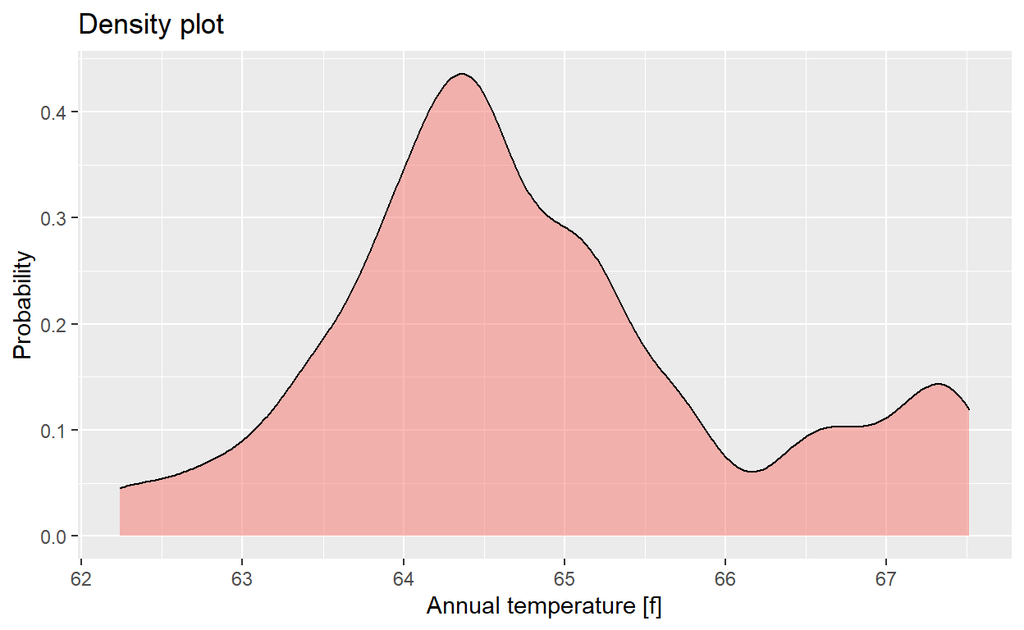

```r
Final_Temperature %>%
ggplot(aes(x = Annual_Temperature)) +
geom_density(aes(fill = "blue"),
show.legend = F,
alpha = .5) +
labs(title = "Density plot",
x = "Annual temperature [f]",
y = "Probability")
```

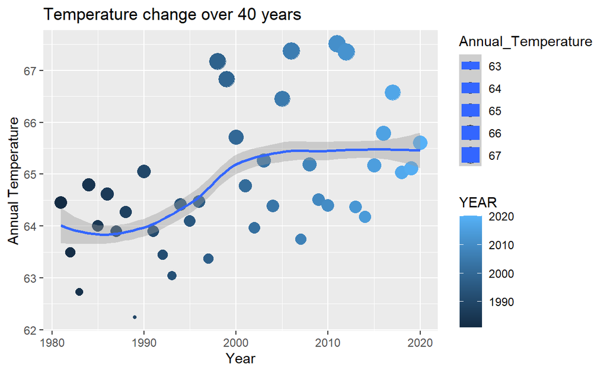

```r
Final_Temperature %>%
filter(Annual_Temperature > 50) %>%
ggplot(aes(x= YEAR,
y = Annual_Temperature,
size = Annual_Temperature,
color = YEAR)) +
geom_point() +
  geom_smooth() +
labs(title = "Temperature change over 40 years",
x = "Year",
y = "Annual Temperature")
```

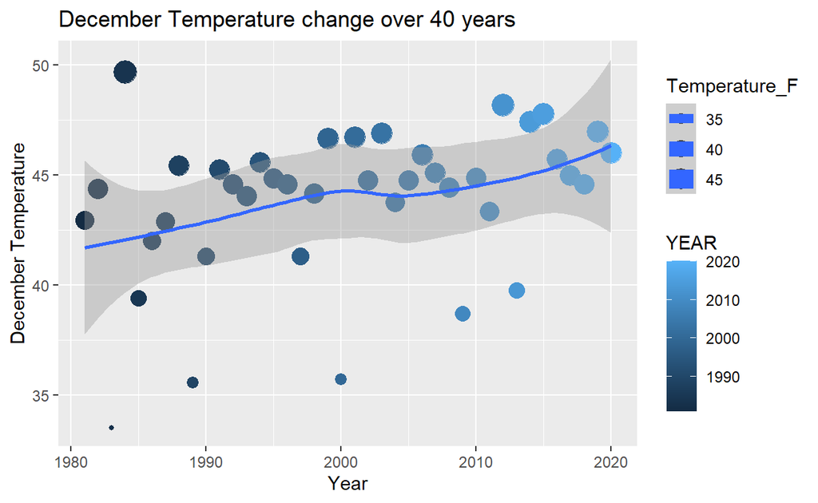

```r
Temperature_DEC %>%
ggplot(aes(x= YEAR,
y = Temperature_F,
size = Temperature_F,
color = YEAR)) +
geom_point() +
  geom_smooth() +
labs(title = "December Temperature change over 40 years",
x = "Year",
y = "December Temperature")
```

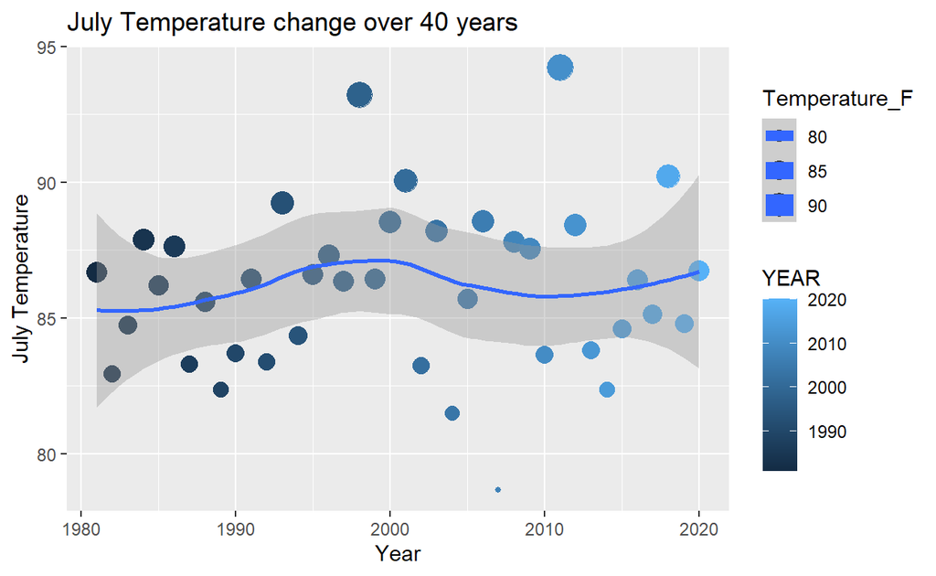

```r
Temperature_July %>%
ggplot(aes(x= YEAR,
y = Temperature_F,
size = Temperature_F,
color = YEAR)) +
geom_point() +
  geom_smooth() +
labs(title = "July Temperature change over 40 years",
x = "Year",
y = "July Temperature")
```

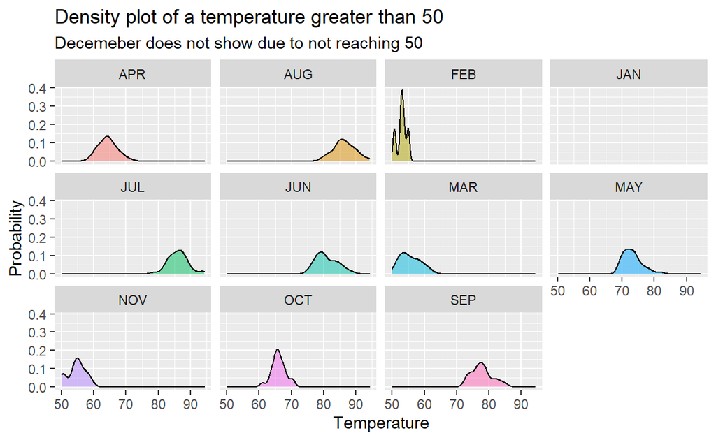

```r
Final_Temperature %>%
drop_na(Temperature_F) %>%
filter(Temperature_F > 50) %>%
ggplot(aes(Temperature_F, fill = MONTH)) +
geom_density(alpha = 0.5) +
facet_wrap(~MONTH) +
labs(title = "Density plot of a temperature greater than 50",
subtitle = "Decemeber does not show due to not reaching 50",
x = "Temperature",
y = "Probability") +
theme(legend.position = "none")
```

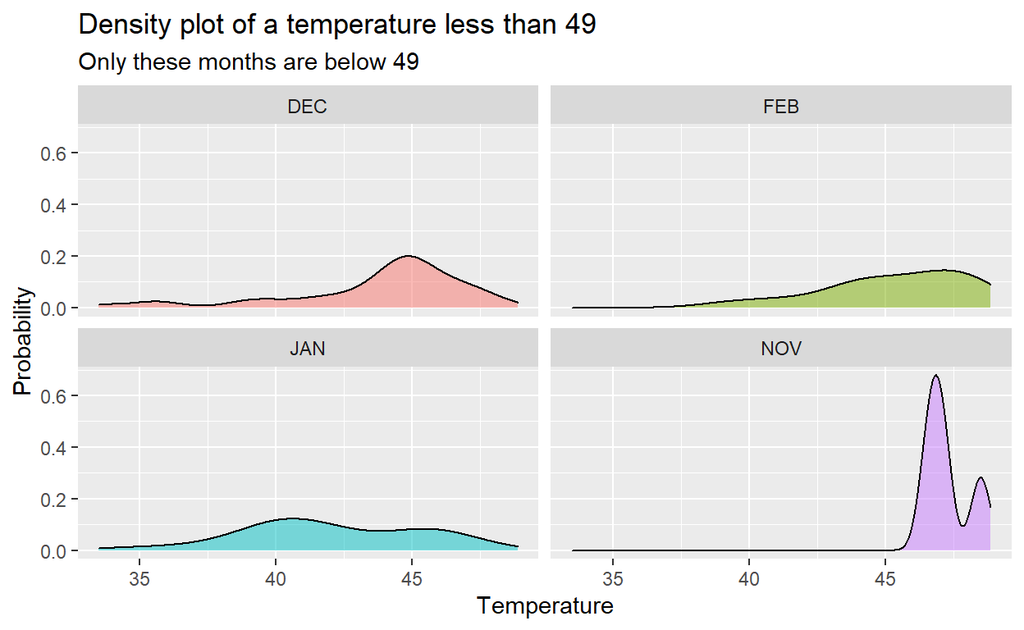

```r
Final_Temperature %>%
drop_na(Temperature_F) %>%
filter(Temperature_F < 49) %>%
ggplot(aes(Temperature_F, fill = MONTH)) +
geom_density(alpha = 0.5) +
facet_wrap(~MONTH) +
labs(title = "Density plot of a temperature less than 49",
subtitle = "Only these months are below 49",
x = "Temperature",
y = "Probability") +
theme(legend.position = "none")
```

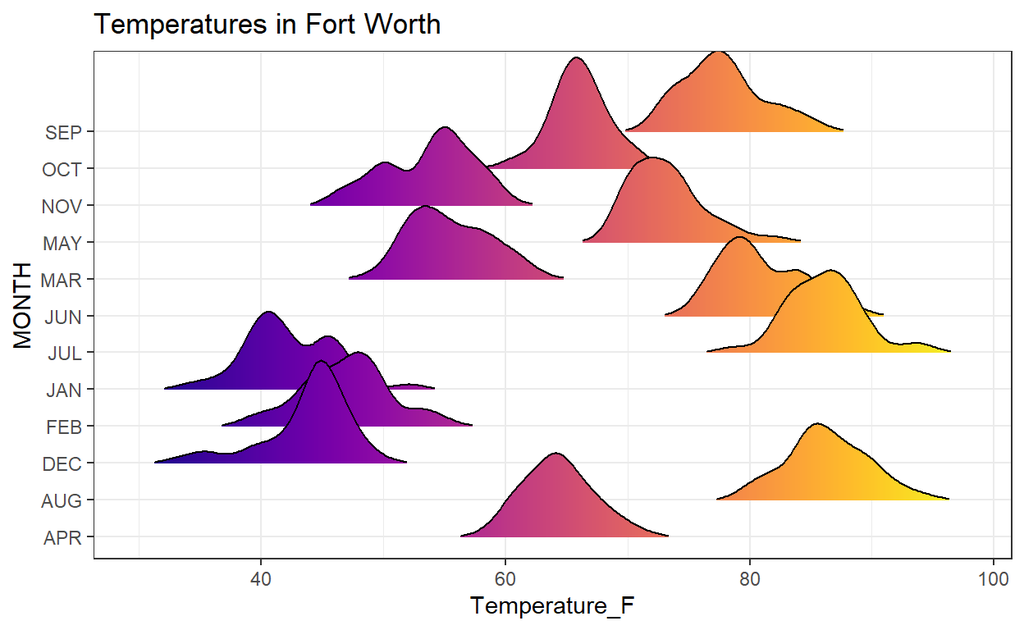

```r
Final_Temperature %>%
ggplot(mapping = aes(x = Temperature_F , y = MONTH, fill = ..x..)) +
geom_density_ridges_gradient(scale = 3, rel_min_height = 0.01,
alpha = 5) +
scale_fill_viridis(name = "Temp. [F]", option = "C") +
labs(title = 'Temperatures in Fort Worth') +
theme_bw() +
theme(legend.position="none",
  panel.spacing = unit(0.1, "lines"),
  strip.text.x = element_text(size = 8))
```

## Insights

I will start with temperature and I will need the columns YEAR, MONTH, ANN, and T2m. This will show the year that it occurred and the month. The t2m will show the temperature at 2meters above the surface level and will display it per month. The Ann will show the average for the year and this is good to use when looking at each year to get a comparison. The temperature column has NA values and is in C format so we need to rename the column and remove the Na values while switching it to F format.

# Cleaning Humidty

```r
# renaming the columns
Final_Humidity <- Para_split %>%
  rename(Humidity = RH2M) %>%
  rename(Annual_Humidity_percent = ANN) %>%
  select(YEAR, MONTH, Humidity, Annual_Humidity_percent) %>%
  na.omit(Humidity)

Final_Humidity %>%
  slice(1:12) %>%
  knitr::kable(caption = "Humidity", digits = 2) %>%
  kableExtra::kable_styling(bootstrap_options = "striped", full_width = TRUE)
```

Table 3: Humidity

| YEAR | MONTH | Humidity | Annual_Humidity_percent |
| --- | --- | --- | --- |
| 1981 | NOV | 80.19 | 68.81 |
| 1981 | JAN | 69.38 | 68.81 |
| 1981 | FEB | 67.19 | 68.81 |
| 1981 | MAR | 67.38 | 68.81 |
| 1981 | APR | 66.19 | 68.81 |
| 1981 | MAY | 71.12 | 68.81 |
| 1981 | JUN | 75.50 | 68.81 |
| 1981 | JUL | 57.81 | 68.81 |
| 1981 | AUG | 50.06 | 68.81 |
| 1981 | SEP | 63.50 | 68.81 |
| 1981 | OCT | 79.62 | 68.81 |
| 1981 | DEC | 78.31 | 68.81 |

```r
# When was humidity the highest (Jan of 1998)

Final_Humidity %>%
  select(YEAR, MONTH, Humidity, Annual_Humidity_percent) %>%
  arrange(desc(Humidity)) %>%
  slice(1:12) %>%
  knitr::kable(caption = "Highest Humidty", digits = 2) %>%
  kableExtra::kable_styling(bootstrap_options = "striped", full_width = TRUE)
```

Table 3: Highest Humidty

| YEAR | MONTH | Humidity | Annual_Humidity_percent |
| --- | --- | --- | --- |
| 1998 | JAN | 86.56 | 66.31 |
| 1991 | DEC | 86.50 | 71.12 |
| 1994 | DEC | 85.69 | 70.50 |
| 1984 | DEC | 85.62 | 62.44 |
| 2015 | MAY | 84.88 | 71.38 |
| 1992 | JAN | 84.75 | 72.75 |
| 2018 | OCT | 84.69 | 68.62 |
| 1986 | DEC | 83.62 | 69.62 |
| 1993 | JAN | 83.56 | 69.56 |
| 2001 | JAN | 83.38 | 69.50 |
| 2001 | FEB | 83.38 | 69.50 |
| 1992 | FEB | 83.25 | 72.75 |

```r
# When was humidity the lowest (Aug of 2000)

Final_Humidity %>%
  select(YEAR, MONTH, Humidity, Annual_Humidity_percent) %>%
  arrange(Humidity) %>%
  na.omit(Humidity) %>%
  slice(1:12) %>%
  knitr::kable(caption = "Lowest Humidity", digits = 2) %>%
  kableExtra::kable_styling(bootstrap_options = "striped", full_width = TRUE)
```

Table 3: Lowest Humidity

| YEAR | MONTH | Humidity | Annual_Humidity_percent |
| --- | --- | --- | --- |
| 2000 | AUG | 34.88 | 63.00 |
| 1999 | AUG | 35.81 | 61.38 |
| 2011 | JUL | 36.19 | 56.44 |
| 2011 | AUG | 37.31 | 56.44 |
| 1985 | AUG | 37.62 | 68.12 |
| 2000 | SEP | 40.44 | 63.00 |
| 2011 | SEP | 41.06 | 56.44 |
| 1998 | JUL | 41.25 | 66.31 |
| 1984 | JUL | 41.31 | 62.44 |
| 1988 | AUG | 44.06 | 61.31 |
| 2011 | JUN | 44.81 | 56.44 |
| 1993 | AUG | 45.00 | 69.56 |

```r
Final_Humidity %>%
  select(YEAR, MONTH, Humidity, Annual_Humidity_percent) %>%
  filter(YEAR < 1983, YEAR > 1981) %>%
  mutate(Mean = mean(Humidity)) %>%
  mutate(Standard_Deviation = sd(Humidity)) %>%
  mutate(Median = median(Humidity)) %>%
  slice(1:12) %>%
  knitr::kable(caption = "Humidty stats data", digits = 2) %>%
  kableExtra::kable_styling(bootstrap_options = "striped", full_width = TRUE)
```

Table 3: Humidty stats data

| YEAR | MONTH | Humidity | Annual_Humidity_percent | Mean | Standard_Deviation | Median |
| --- | --- | --- | --- | --- | --- | --- |
| 1982 | NOV | 70.38 | 67.88 | 67.97 | 10.97 | 70.28 |
| 1982 | JAN | 70.19 | 67.88 | 67.97 | 10.97 | 70.28 |
| 1982 | FEB | 78.69 | 67.88 | 67.97 | 10.97 | 70.28 |
| 1982 | MAR | 73.94 | 67.88 | 67.97 | 10.97 | 70.28 |
| 1982 | APR | 66.81 | 67.88 | 67.97 | 10.97 | 70.28 |
| 1982 | MAY | 79.69 | 67.88 | 67.97 | 10.97 | 70.28 |
| 1982 | JUN | 77.81 | 67.88 | 67.97 | 10.97 | 70.28 |
| 1982 | JUL | 65.75 | 67.88 | 67.97 | 10.97 | 70.28 |
| 1982 | AUG | 49.00 | 67.88 | 67.97 | 10.97 | 70.28 |
| 1982 | SEP | 48.31 | 67.88 | 67.97 | 10.97 | 70.28 |
| 1982 | OCT | 58.19 | 67.88 | 67.97 | 10.97 | 70.28 |
| 1982 | DEC | 76.88 | 67.88 | 67.97 | 10.97 | 70.28 |

## Graphing Humidity

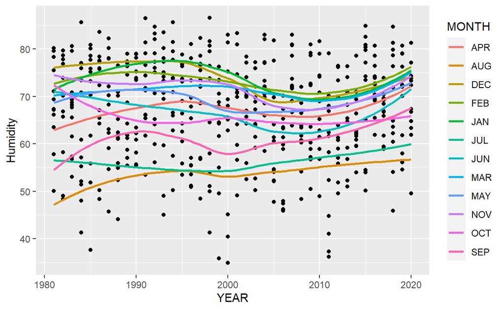

```r
# change in humidity over years by each month

ggplot(data = Final_Humidity, mapping = aes(x = YEAR, y = Humidity)) +
  geom_point() +
  geom_smooth(mapping = aes(color = MONTH), se = FALSE)
```

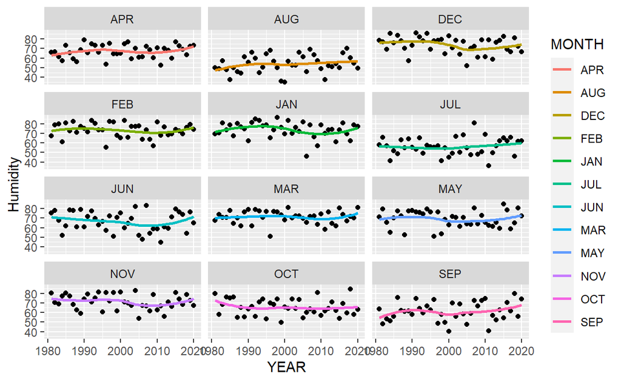

```r
# Facet wrap of the previous graph to separate them

ggplot(data = Final_Humidity, mapping = aes(x = YEAR, y = Humidity)) +
  geom_point() +
  geom_smooth(mapping = aes(color = MONTH), se = FALSE) +
  facet_wrap(~ MONTH, nrow = 5)
```

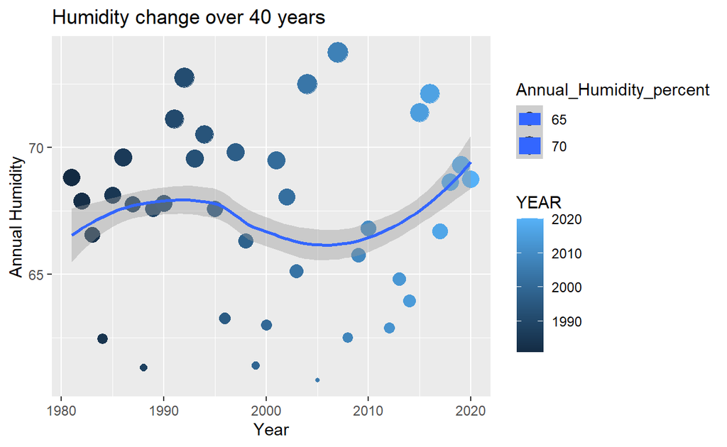

```r
Final_Humidity %>%
filter(Annual_Humidity_percent > 60) %>%
ggplot(aes(x= YEAR,
y = Annual_Humidity_percent,
size = Annual_Humidity_percent,
color = YEAR)) +
geom_point() +
  geom_smooth() +
labs(title = "Humidity change over 40 years",
x = "Year",
y = "Annual Humidity")
```

## Insights

Here we are doing the same thing that we did to the previous section of temperature. We renamed the RH2m to humidity and then changed the ANN to annual_humidity_percent. Next we removed the na values to focus in on the information that we needed and then graphed it to start drawing conclusions.

# Cleaning Precipitation

```r
# changing the precipitation from mm to inches and then renaming.
Final_Precipitation <- Para_split %>%
  rename(Precipitation = PRECTOTCORR_SUM) %>%
  mutate(Precipitation_annual = ANN / 25.4) %>%
  mutate(Precipitation_Monthly = Precipitation / 25.4) %>%
  select(YEAR, MONTH, Precipitation_Monthly, Precipitation_annual) %>%
  na.omit(Precipitation_Monthly)

Final_Precipitation %>%
  slice(1:12) %>%
  knitr::kable(caption = "Precipitation (Inches)", digits = 2) %>%
  kableExtra::kable_styling(bootstrap_options = "striped", full_width = TRUE)
```

Table 4: Precipitation (Inches)

| YEAR | MONTH | Precipitation_Monthly | Precipitation_annual |
| --- | --- | --- | --- |
| 1981 | NOV | 1.53 | 42.61 |
| 1981 | JAN | 0.39 | 42.61 |
| 1981 | FEB | 1.82 | 42.61 |
| 1981 | MAR | 3.33 | 42.61 |
| 1981 | APR | 3.04 | 42.61 |
| 1981 | MAY | 6.08 | 42.61 |
| 1981 | JUN | 4.05 | 42.61 |
| 1981 | JUL | 1.42 | 42.61 |
| 1981 | AUG | 2.12 | 42.61 |
| 1981 | SEP | 2.98 | 42.61 |
| 1981 | OCT | 15.63 | 42.61 |
| 1981 | DEC | 0.21 | 42.61 |

```r
# When was precipitation the highest (OCT of 1981)

Final_Precipitation %>%
  select(YEAR, MONTH, Precipitation_Monthly, Precipitation_annual) %>%
  arrange(desc(Precipitation_Monthly)) %>%
  na.omit(Precipitation_Monthly) %>%
  slice(1:12) %>%
  knitr::kable(caption = "Highest Precipitation (Inches)", digits = 2) %>%
  kableExtra::kable_styling(bootstrap_options = "striped", full_width = TRUE)
```

Table 4: Highest Precipitation (Inches)

| YEAR | MONTH | Precipitation_Monthly | Precipitation_annual |
| --- | --- | --- | --- |
| 1981 | OCT | 15.63 | 42.61 |
| 2015 | MAY | 15.24 | 57.96 |
| 1982 | MAY | 11.28 | 38.48 |
| 1989 | MAY | 10.61 | 43.01 |
| 2018 | OCT | 10.43 | 40.07 |
| 2004 | JUN | 10.23 | 45.36 |
| 2007 | JUN | 10.17 | 44.77 |
| 1989 | JUN | 9.64 | 43.01 |
| 1990 | APR | 9.36 | 46.70 |
| 1991 | DEC | 8.75 | 47.55 |
| 1991 | OCT | 8.74 | 47.55 |
| 2009 | OCT | 8.69 | 38.44 |

```r
# When was it the lowest (Jan of 1986)

Final_Precipitation %>%
  select(YEAR, MONTH, Precipitation_Monthly, Precipitation_annual) %>%
  arrange(Precipitation_Monthly) %>%
  na.omit(Precipitation_Monthly) %>%
  slice(1:12) %>%
  knitr::kable(caption = "Lowest Precipitation (Inches)", digits = 2) %>%
  kableExtra::kable_styling(bootstrap_options = "striped", full_width = TRUE)
```

Table 4: Lowest Precipitation (Inches)

| YEAR | MONTH | Precipitation_Monthly | Precipitation_annual |
| --- | --- | --- | --- |
| 1986 | JAN | 0.01 | 39.02 |
| 2011 | JUL | 0.01 | 22.53 |
| 2000 | AUG | 0.02 | 32.05 |
| 2011 | MAR | 0.08 | 22.53 |
| 1993 | JUL | 0.08 | 36.92 |
| 2012 | NOV | 0.12 | 28.73 |
| 2018 | JAN | 0.17 | 40.07 |
| 2014 | JAN | 0.18 | 23.94 |
| 2005 | NOV | 0.19 | 18.28 |
| 1981 | DEC | 0.21 | 42.61 |
| 2005 | DEC | 0.21 | 18.28 |
| 1996 | FEB | 0.21 | 33.81 |

```r
Stats_precipitation <- Final_Precipitation %>%
  select(YEAR, MONTH, Precipitation_Monthly, Precipitation_annual) %>%
  filter(YEAR < 1982) %>%
  mutate(Mean = mean(Precipitation_Monthly)) %>%
  mutate(Standard_Deviation = sd(Precipitation_Monthly)) %>%
  mutate(Median = median(Precipitation_Monthly))

Stats_precipitation %>%
  slice(1:12) %>%
  knitr::kable(caption = "Precipitation stats data (Inches)", digits = 2) %>%
  kableExtra::kable_styling(bootstrap_options = "striped", full_width = TRUE)
```

Table 4: Precipitation stats data (Inches)

| YEAR | MONTH | Precipitation_Monthly | Precipitation_annual | Mean | Standard_Deviation | Median |
| --- | --- | --- | --- | --- | --- | --- |
| 1981 | NOV | 1.53 | 42.61 | 3.55 | 4.13 | 2.55 |
| 1981 | JAN | 0.39 | 42.61 | 3.55 | 4.13 | 2.55 |
| 1981 | FEB | 1.82 | 42.61 | 3.55 | 4.13 | 2.55 |
| 1981 | MAR | 3.33 | 42.61 | 3.55 | 4.13 | 2.55 |
| 1981 | APR | 3.04 | 42.61 | 3.55 | 4.13 | 2.55 |
| 1981 | MAY | 6.08 | 42.61 | 3.55 | 4.13 | 2.55 |
| 1981 | JUN | 4.05 | 42.61 | 3.55 | 4.13 | 2.55 |
| 1981 | JUL | 1.42 | 42.61 | 3.55 | 4.13 | 2.55 |
| 1981 | AUG | 2.12 | 42.61 | 3.55 | 4.13 | 2.55 |
| 1981 | SEP | 2.98 | 42.61 | 3.55 | 4.13 | 2.55 |
| 1981 | OCT | 15.63 | 42.61 | 3.55 | 4.13 | 2.55 |
| 1981 | DEC | 0.21 | 42.61 | 3.55 | 4.13 | 2.55 |

## Graphing Precipitation

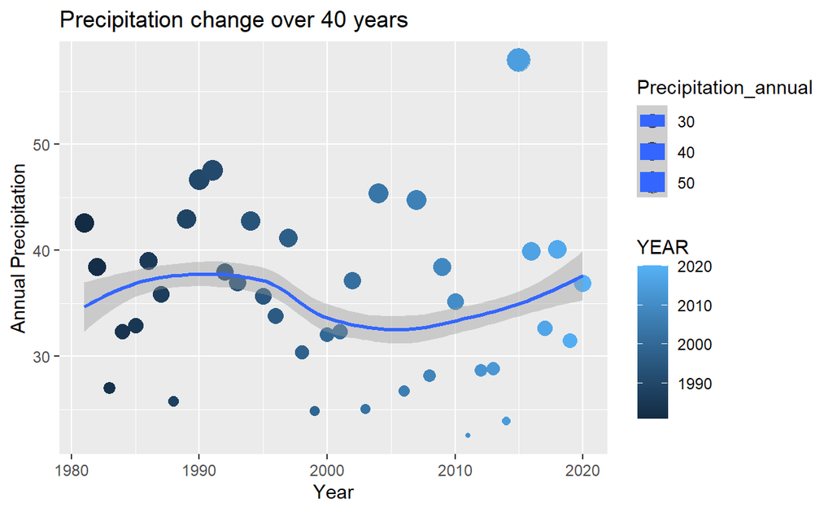

```r
Final_Precipitation %>%
filter(Precipitation_annual > 20) %>%
ggplot(aes(x= YEAR,
y = Precipitation_annual,
size = Precipitation_annual,
color = YEAR)) +
geom_point() +
  geom_smooth() +
labs(title = "Precipitation change over 40 years",
x = "Year",
y = "Annual Precipitation")
```

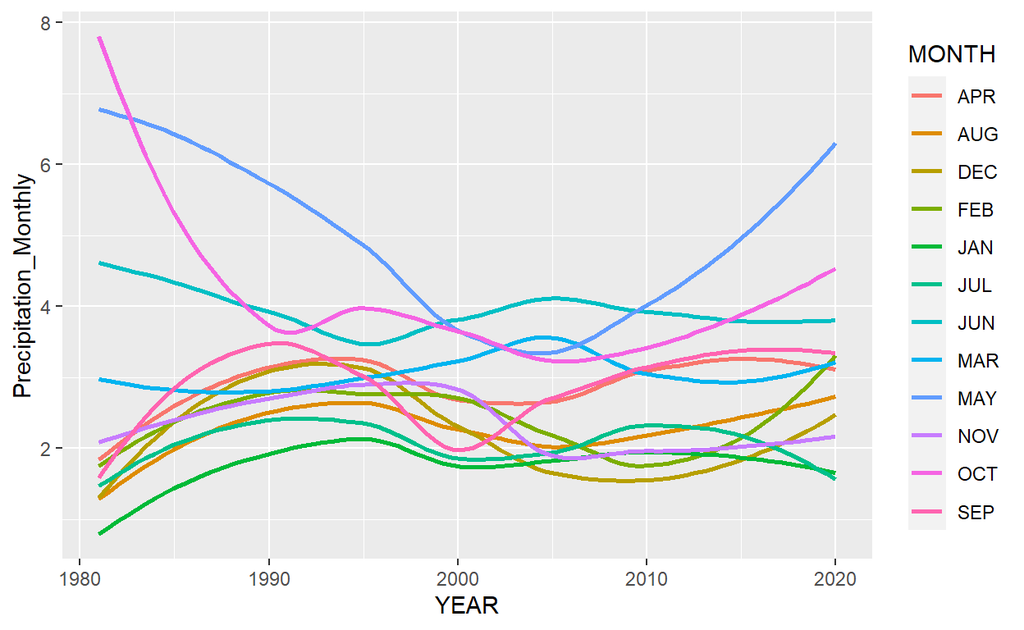

```r
ggplot(data = Final_Precipitation, mapping = aes(x = YEAR, y = Precipitation_Monthly)) +
  geom_smooth(mapping = aes(color = MONTH), se = FALSE)
```

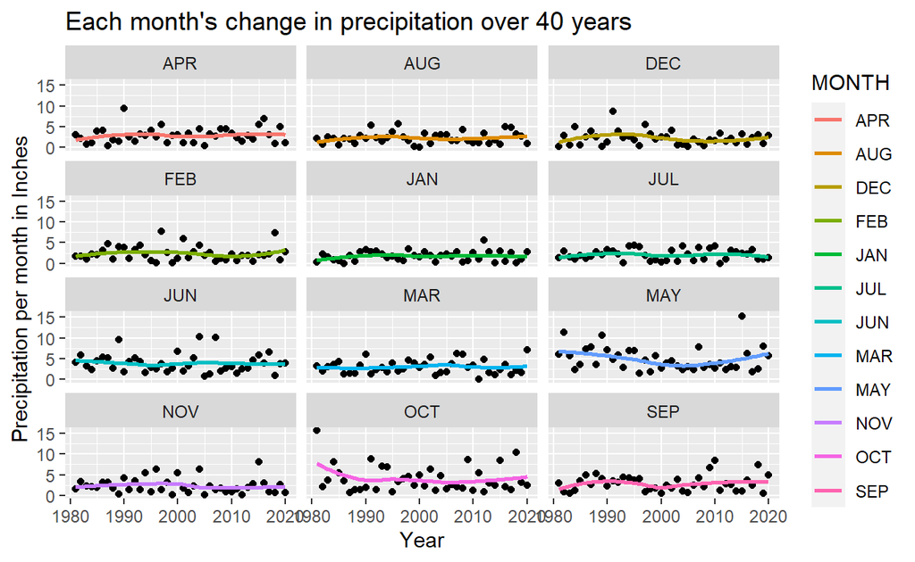

```r
# Facet grid by month of the precipitation changes over the years

ggplot(data = Final_Precipitation, mapping = aes(x = YEAR, y = Precipitation_Monthly)) +
  geom_point() +
  geom_smooth(mapping = aes(color = MONTH), se = FALSE) +
  facet_wrap(~ MONTH, nrow = 5) +
  labs(title = "Each month's change in precipitation over 40 years", x = "Year", y = "Precipitation per month in Inches")
```